# Allen Hippocampus DEGs

Kennedi Todd

2/15/2021

Set working directory.

Load necessary packages.

```r
library(BiocParallel)
library(data.table)
library(edgeR)
```

```r
library(ggplot2)
library(ggrepel) # geom_text_repel()
library(gplots) # heatmap.2()
library(grid)
library(gridExtra)
library(knitr)
library(limma)
library(MatchIt)
library(rtracklayer)
library(variancePartition)
```

Read in files.

```r
# counts already in TPM
counts <- read.delim("hippocampus_tpm_counts.txt", header = TRUE, sep = "\t")
gene.info <- read.delim("geneInfo.txt", header = TRUE, sep = "\t")
metadata <- read.delim("hippocampus_metadata.txt", header = TRUE, sep = "\t")
```

Reformat

```r
# Check that row names of counts file matches gene_id in gene.info
all.equal(rownames(counts),as.character(gene.info$gene_id))
```

```
## [1] TRUE
```

```r
# Returned true so rename rows with gene_symbol
rownames(counts) <- gene.info$gene_symbol

# Check that column names of counts file matches donor_id in metadata
all.equal(colnames(counts), as.character(make.names(metadata$donor_id)))
```

```
## [1] TRUE
```

Create DGE object with our counts, gene.info and metadata.

```r
dge <- DGEList(counts = counts, genes = gene.info, samples = metadata)
dim(dge)
```

```
## [1] 50283    94
```

Remove MT genes. They’re super abundant and can skew data. Allen’s annotation file did not provide an easy way to identify chr #. We know that NC_012920.1 refers to the MT based on the link below. We also expect there to be 37 genes.

https://www.ncbi.nlm.nih.gov/assembly/GCF_000001405.28/#/def

```r
table(gene.info$seqnames == "NC_012920.1")
```

```
##
## FALSE  TRUE
## 50246    37
```

```r
keep <- gene.info$seqnames != "NC_012920.1"
dge <- dge[keep,]
dim(dge)
```

```
## [1] 50246    94
```

We now have 50,246 genes.

Only some of the ages are binned. Bin the rest of the data.

```r
table(dge$samples$age)
```

```
##
##  100+    77    78    79    81    82    83    84    85    86    87    88    89
##     7     1     9     2     3     2     1     4     2     4     3     6     8
## 90-94 95-99
##    27    15
```

```r
donor_ages <- dge$samples$age
bin_ages <- vector()

for (i in 1:length(donor_ages)){
  x <- donor_ages[i]
  if (x == "77" |
      x == "78" |
      x == "79") {
        bin_ages <- c(bin_ages, "75_79")
  }
  else if (x == "81" |
      x == "82" |
      x == "83" |
      x == "84") {
        bin_ages <- c(bin_ages, "80_84")
  }
  else if (x == "85" |
      x == "86" |
      x == "87" |
      x == "88" |
      x == "89") {
        bin_ages <- c(bin_ages, "85_89")
  }
  else if (x == "85" |
      x == "86" |
      x == "87" |
      x == "88" |
      x == "89") {
        bin_ages <- c(bin_ages, "85_89")
  }
  else if (x == "90-94") {
        bin_ages <- c(bin_ages, "90_94")
  }
  else if (x == "95-99") {
        bin_ages <- c(bin_ages, "95_99")
  }
  else {
    bin_ages <- c(bin_ages, "100_")
  }
}
```

```r
as.data.frame(cbind(donor_ages,bin_ages)) #check
```

```
##    donor_ages bin_ages
## 1       90-94    90_94
## 2       90-94    90_94
## 3       90-94    90_94
## 4       90-94    90_94
## 5       90-94    90_94
## 6       90-94    90_94
## 7       90-94    90_94
## 8       90-94    90_94
## 9        100+     100_
## 10       100+     100_
## 11         86    85_89
## 12      90-94    90_94
## 13         81    80_84
## 14         79    75_79
```

[output cut: 80 more lines]

```r
dge$samples$age <- factor(bin_ages)
```

Reformat type of sample columns.

```r
sample_columns <- c(1, 7:24)
dge$samples[sample_columns] <-
  lapply(dge$samples[sample_columns], factor)
```

—————————–TTR TPM HISTOGRAMS———————————

Data is already in TPM (transcripts per million). Create histogram of TPM TTR values.

```r
ttr.counts <- as.data.frame(dge$counts["TTR",])
colnames(ttr.counts) <- "ttr.counts"
log2.ttr.counts <- log2(ttr.counts + 0.01)
colnames(log2.ttr.counts) <- "log2.ttr.counts"
```

```r
h1 <- ggplot(ttr.counts, aes(x = ttr.counts)) +
  geom_histogram(bins = 100, fill = "gray", color = "black") +
  labs(title = "A.", x=NULL, y=NULL) +
  xlab("TTR TPM") + ylab("# of Samples") +
  geom_vline(xintercept = 20, col = "red") +
  theme_bw()

h2 <- ggplot(ttr.counts, aes(x = ttr.counts)) +
  geom_histogram(bins = 100, fill = "gray", color = "black") +
  labs(title = "B.", x=NULL, y=NULL) +
  xlab("TTR TPM") + ylab("# of Samples") +
  xlim(0, 50) + geom_vline(xintercept = 20, col = "red") +
  theme_bw()

h3 <- ggplot(log2.ttr.counts, aes(x = log2.ttr.counts)) +
  geom_histogram(bins = 100, fill = "gray", color = "black") +
  labs(title = "Allen Brain Atlas\nAging, Dementia and TBI\nHippocampus",
       x=NULL, y=NULL) +
  xlab("log2(TTR TPM)") + ylab("# of Samples") + theme_bw() +
  geom_vline(xintercept = log2(20) + 1, col = "blue") +
  geom_vline(xintercept = log2(20) - 1, col = "blue")
```

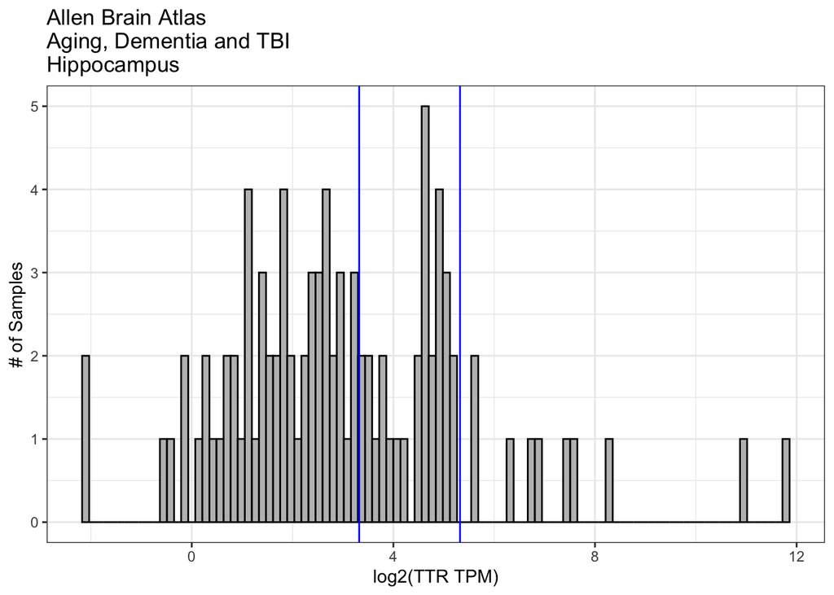

```r
h3
```

Arrange graphs in grid.

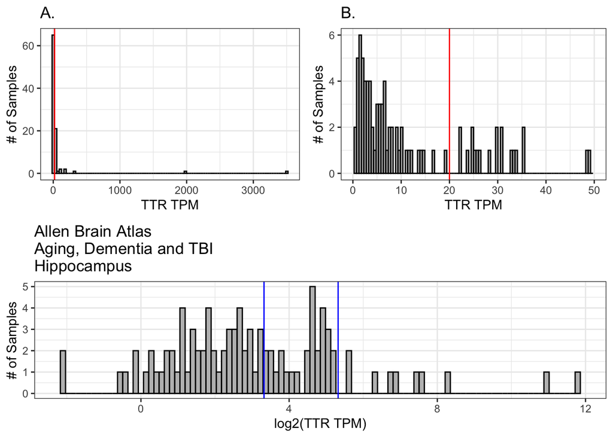

```r
plots1 <- list(h1,h2,h3)

layout1 <- rbind(c(1,2),c(3))

grid1 <- grid.arrange(grobs = plots1, layout_matrix = layout1)
```

——————————ASSIGN DIRTY/CLEAN/NEITHER————————

Lets looks at groups +/- 1 of the cutoff

```r
clean_threshold <- log2(20) - 1 # values <= this are clean
clean_threshold
```

```
## [1] 3.321928
```

```r
cutoff <- log2(20)
cutoff
```

```
## [1] 4.321928
```

```r
dirty_threshold <- log2(20) + 1 # values >= this are dirty
dirty_threshold
```

```
## [1] 5.321928
```

Assign clean or dirty

```r
clean_or_dirty <- vector()
vector.log2.ttr.counts <- as.vector(log2.ttr.counts$log2.ttr.counts)

for (i in 1:length(vector.log2.ttr.counts)){
  if (vector.log2.ttr.counts[i] <= clean_threshold){
    clean_or_dirty <- c(clean_or_dirty, "clean")
  }
  else if (vector.log2.ttr.counts[i] >= dirty_threshold){
    clean_or_dirty <- c(clean_or_dirty, "dirty")
  }
  else {
    clean_or_dirty <- c(clean_or_dirty, "neither")
  }
}
table(clean_or_dirty)
```

```
## clean_or_dirty
##   clean   dirty neither
##      58      10      26
```

```r
dge$samples$group <- factor(clean_or_dirty)
head(dge$samples)
```

```
##              group  lib.size norm.factors  donor_id donor_name specimen_id
## X309335438   dirty 1000000.2            1 309335438 H14.09.001   309357595
## X309335439   clean 1000000.3            1 309335439 H14.09.002   309357603
## X309335440 neither  999999.5            1 309335440 H14.09.003   309357615
## X309335441   clean  999999.7            1 309335441 H14.09.004   309357620
## X309335442   clean 1000000.2            1 309335442 H14.09.005   309357631
## X309335443   dirty 1000000.1            1 309335443 H14.09.006   309357639
##                specimen_name  rna_well rna_integrity_number structure_id
## X309335438 H14.09.001.HIP.05 320630832                  7.3        10294
## X309335439 H14.09.002.HIP.01 320630842                  6.4        10294
## X309335440 H14.09.003.HIP.03 320630856                  6.5        10294
## X309335441 H14.09.004.HIP.01 320630858                  7.7        10294
## X309335442 H14.09.005.HIP.01 320630973                  6.3        10294
## X309335443 H14.09.006.HIP.03 320630985                  6.7        10294
##            structure_acronym                      structure_name
## X309335438               HIP hippocampus (hippocampal formation)
## X309335439               HIP hippocampus (hippocampal formation)
## X309335440               HIP hippocampus (hippocampal formation)
## X309335441               HIP hippocampus (hippocampal formation)
## X309335442               HIP hippocampus (hippocampal formation)
## X309335443               HIP hippocampus (hippocampal formation)
##            rnaseq_profile_id rnaseq_total_reads
## X309335438         496100314           32275545
## X309335439         496100281           33402591
## X309335440         496100288           34988573
## X309335441         496100303           33631611
## X309335442         496100313           32693366
## X309335443         496100304           38334077
##            rnaseq_percent_reads_aligned_to_mrna
## X309335438                                 31.7
## X309335439                                 29.5
## X309335440                                 29.5
## X309335441                                 32.9
## X309335442                                 27.9
## X309335443                                 29.6
##            rnaseq_percent_reads_aligned_to_ncrna
## X309335438                                  7.11
## X309335439                                  7.21
## X309335440                                  7.78
## X309335441                                  7.87
```

[output cut: 50 more lines]

```
## X309335443     0             0               No Dementia          16
##                   nincds_arda_diagnosis ever_tbi_w_loc  race     hispanic
## X309335438                  No Dementia              Y White Not Hispanic
## X309335439 Probable Alzheimer'S Disease              N White Not Hispanic
## X309335440                  No Dementia              Y White Not Hispanic
## X309335441                  No Dementia              N White Not Hispanic
## X309335442 Possible Alzheimer'S Disease              Y White Not Hispanic
## X309335443                  No Dementia              N White Not Hispanic
##            act_demented braak nia_reagan
## X309335438  No Dementia     6          2
## X309335439     Dementia     1          1
## X309335440  No Dementia     1          2
## X309335441  No Dementia     3          1
## X309335442     Dementia     5          2
## X309335443  No Dementia     3          1
```

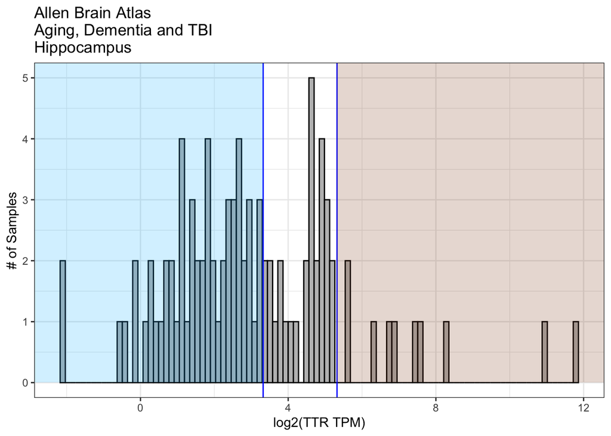

```r
h4 <- h3 +
  annotate("rect",
              xmin = -Inf,
              xmax = clean_threshold,
              ymin = 0,
              ymax=Inf,
              alpha=0.2,
              fill="deepskyblue") +
  annotate("rect",
              xmin = dirty_threshold,
              xmax = Inf,
              ymin = 0,
              ymax=Inf,
              alpha=0.2,
              fill="chocolate4")
h4
```

Write table.

```r
#write.csv(as.data.frame(dge$samples),"metadata_with_groups.txt")
```

———————–FILTER LOWLY EXPRESSED GENES—————————–

TPM to CPM

```r
cpm <- cpm(dge)
```

Filter

```r
# produces a logical matrix
thresh <- cpm > 2 # cpm greater than 2

# keep genes that have at least 3 TRUES in each row of thresh
keep <- rowSums(thresh) >= 3
summary(keep)
```

```
##    Mode   FALSE    TRUE
## logical   28597   21649
```

```r
# redefine object, filter by logical
dge.filtered <- dge[keep, keep.lib.sizes = FALSE]

dim(dge)
```

```
## [1] 50246    94
```

```r
dim(dge.filtered)
```

```
## [1] 21649    94
```

————————–TRIMMED MEAN OF M-VALUES——————————

Now, we want to normalize gene expression distributions. We do this by normalizing library size differences in each sample. The method Trimmed Mean of M-values (TMM) is used with the calcNormFactors in the edgeR package. The normalization factors calculated here are used as a scaling factor for the library size.

Trimmed mean of M values (TMM) normalization estimates sequencing depth after excluding genes for which the ratio of counts between a pair of experiments is too extreme or for which the average expression is too extreme. The edgeR software implements a TMM normalization (Biostar Handbook 2020).

```r
# creates another large DGEList
dge.filtered.norm <- calcNormFactors(dge.filtered, method = "TMM")

# view norm factors
dge.filtered.norm$samples$norm.factors
```

```
##  [1] 1.0202355 1.0273473 0.9690797 0.9791324 1.0189556 1.0020056 0.9949562
##  [8] 1.1350273 1.0862900 0.8722981 1.1777378 1.2483706 1.1526413 0.9629970
## [15] 1.2296797 1.0662488 1.2592338 1.1741954 1.2417907 1.1272806 1.1009500
## [22] 1.0846397 1.1874714 1.1493620 1.1664798 1.1485547 0.9856357 1.1012890
## [29] 0.8797203 0.9261108 1.0344187 0.9373327 0.9894263 1.0458252 1.0942185
## [36] 1.1076009 1.0859050 0.9357779 0.9558353 1.1142858 0.9487877 0.8985089
## [43] 1.0300677 1.0503659 1.0702488 0.9896276 1.0847578 1.0177151 0.8702127
## [50] 0.9953375 0.8924687 0.8808818 0.9434384 0.9354886 1.0021213 0.8085590
## [57] 1.0511462 1.0841253 1.1233353 0.8961911 1.0234197 0.8301074 0.9604787
## [64] 0.8915946 0.9366741 0.9653385 0.8217318 1.0218255 0.9201177 0.8513358
## [71] 0.8946792 0.9208396 0.8223832 0.9097243 0.9607852 1.1360909 0.8020152
## [78] 0.9368025 1.0299258 0.9393515 0.7583634 0.8787716 0.9908674 0.9150066
## [85] 0.9158122 1.0038070 0.7994174 1.1454248 0.9829271 0.9103900 1.0489292
## [92] 1.0677522 1.1428388 1.1010207
```

```r
summary(dge.filtered.norm$samples$norm.factors)
```

```
##    Min. 1st Qu.  Median    Mean 3rd Qu.    Max.
##  0.7584  0.9222  0.9987  1.0062  1.0862  1.2592
```

Looking to be around ~1.

——————————-Variance Partition——————————-

See what options we have to choose from.

```r
colnames(dge.filtered.norm$samples)
```

```
##  [1] "group"
##  [2] "lib.size"
##  [3] "norm.factors"
##  [4] "donor_id"
##  [5] "donor_name"
##  [6] "specimen_id"
##  [7] "specimen_name"
##  [8] "rna_well"
##  [9] "rna_integrity_number"
## [10] "structure_id"
## [11] "structure_acronym"
## [12] "structure_name"
## [13] "rnaseq_profile_id"
## [14] "rnaseq_total_reads"
## [15] "rnaseq_percent_reads_aligned_to_mrna"
```

[output cut: 24 more lines]

Specify variables to consider

```r
#register(SnowParam(4)) # work in parallel

# geneExpr: matrix of gene expression values
# info: information/metadata about each sample
#geneExpr <- as.matrix(dge.filtered.norm$counts)
#info <- as.data.frame(dge.filtered.norm$samples)

# Age is USUALLY continuous so model it as a fixed effect "age"
# However, this metadata categorizes it into bins
# Sex is categorical, so model them as random effects "(1|sex)"
# Note the syntax
#form <- ~ (1|group) +
#  (1|age) +
#  (1|sex) +
#  (1|apo_e4_allele) +
#  (1|cerad) +
#  (1|dsm_iv_clinical_diagnosis) +
#  (1|nincds_arda_diagnosis) +
#  (1|act_demented) +
#  (1|braak) +
#  (1|nia_reagan) +
#  (1|hemisphere)

#varPart <- fitExtractVarPartModel(geneExpr, form, info)
#vp <- sortCols(varPart)

#Violin plots
#plotVarPart(vp)

#table(dge.filtered$samples$dsm_iv_clinical_diagnosis)

#Percent bars

#plotPercentBars(vp[1:10,])
```

```r
# sort genes based on variance explained by group
#varPart.df <- as.data.frame(varPart)
#order.varPart.df <- varPart.df[order(varPart.df$group, #decreasing = TRUE),]
#order.varPart.df["group"]
```

—————————–DESIGN MATRIX————————————–

```r
sex <- dge.filtered.norm$samples$sex
age <- dge.filtered.norm$samples$age
```

Create a design matrix and specify the samples we want to compare to each other.

```r
# interaction computes a factor which represents the interaction of the given factors
group <- interaction(dge.filtered$samples$group)

design <- model.matrix(~ 0 + group + sex + age)
colnames(design)[1:2] <- c("clean","dirty")
```

Run voom with quality weights. This combines observational-level weights with sample-specific quality weights in an experiment. Normalizes expression intensities so that the log-ratios have similar distributions across a set of samples. To quantile normalize, add normalize.method = “quantile”.

Quality weights in RNA-seq data improves data quality when samples with high variance are present. This variation is modeled by taking into account global intensity-dependent trends using voom.  
Sample-specific variability is taken into account with a log-linear model that shares parameters between genes. https://doi.org/10.1093/nar/gkv412

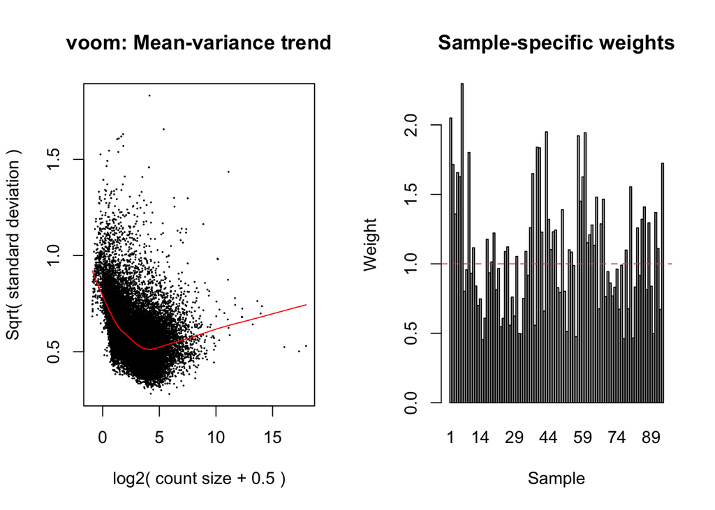

```r
v <- voomWithQualityWeights(dge.filtered.norm, design, plot = TRUE)
```

———————————MDS PLOT—————————————

```r
#create a png file# png(filename = "mds_1and2.png", width = 400, height = 400)
#default height and width are 480, default units are "px" (pixels)

group_colors <- c("deepskyblue","chocolate4","gray")[v$targets$group] # blue is clean, brown is dirty
point_shapes <- c("F","M")[v$targets$sex] # will say F or M for points
head(data.frame(v$targets$group, group_colors, v$targets$sex,point_shapes)) # Check everything matches
```

```
##   v.targets.group group_colors v.targets.sex point_shapes
## 1           dirty   chocolate4             M            M
## 2           clean  deepskyblue             M            M
## 3         neither         gray             M            M
## 4           clean  deepskyblue             M            M
## 5           clean  deepskyblue             F            F
## 6           dirty   chocolate4             F            F
```

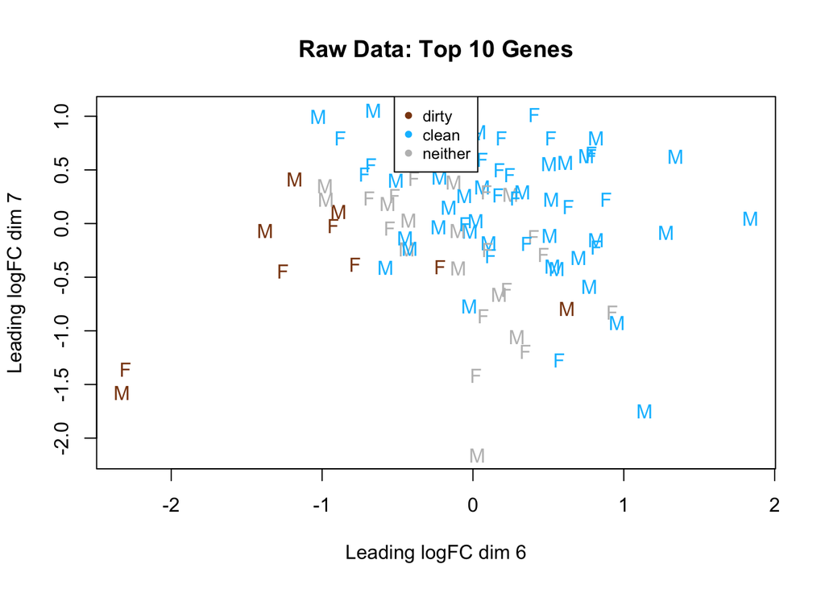

```r
mds <- plotMDS(
  v, # our data object
  top = 10, # only looking at top 10 genes
  pch = point_shapes,
  cex = 1, # point size
  dim.plot = c(6,7), # specifying principal components to be plotted
  plot = TRUE, # if TRUE then plot is created on current graphics device
  col = group_colors # assigning our colors for each genotype
)

legend(
  "top",
  pch = 16,
  legend = unique(factor(v$targets$group)),
  col = group_colors,
  cex = 0.8
)

title("Raw Data: Top 10 Genes")
```

————————-HIERARCHIAL HEAT CLUSTERING—————————-

```r
current_order <- dge.filtered.norm$samples$X_donor_id

# reorder levels
group_order <- dge.filtered.norm$samples
group_order <- group_order[order(factor(group, levels = c("dirty","neither","clean"))),]
sample_group_order <- group_order$X_donor_id
dge.group <- dge.filtered.norm[,sample_group_order]

# sample group colors
sample_group_color <- c("deepskyblue", "chocolate4", "gray")[dge.group$samples$group]
as.data.frame(dge.group$samples$group, sample_group_color)
```

```
## [1] dge.group$samples$group
## <0 rows> (or 0-length row.names)
```

```r
# We estimate the variance for each row in the logcounts matrix
#logcounts <- cpm(dge.group, log = TRUE) # log2 values
#var_genes <- apply(logcounts, 1, var)

# Get the gene names for the top 100 most variable genes
#select_var <- names(sort(var_genes, decreasing=TRUE))[1:50]
#select_var

# Subset logcounts matrix
#highly_variable_lcpm <- logcounts[select_var,]
```

```r
#my_palette <- colorRampPalette(c("red", "black", "green"))

# Plot the heatmap
#map <- heatmap.2(highly_variable_lcpm,
#          main = "Top 50 most variable genes across samples",
#          col = my_palette, # heatmap color scale
#          ColSideColors = sample_group_color,
#          trace = "none",
#          dendrogram = "row",
 #         Colv = sample_group_order,
 #         colCol = sample_group_color,
 #         srtCol = 45,
 #         xlab = "Samples"
 #         )
```

———————————LINEAR MODELS———————————-

Fit linear models for comparisons of interest. Linear modeling in limma is carried out using the lmFit and contrasts.fit functions.

What do lm.fit and contrasts.fit do? 1) Fit a separate model to the expression values for each gene. 2) An empirical Bayes moderation is carried out by borrowing info across all the gene to obtain more precise estimates of gene-wise variability. 3) The model’s residual variances are plotted against average expression values in the next figure.

It can be seen from this plot that the variance is no longer dependent on the mean expression level.

```r
# Fits linear model for each gene given a series of arrays
fit <- lmFit(
  v,  # object containing log-expression values for a series of arrays
  design  # design matrix
  )
```

Contrast design for differential expression.

```r
contrasts <-
  makeContrasts(
    dirty_vs_clean = dirty - clean,
    levels = colnames(design)
  )

head(contrasts)
```

```
##               Contrasts
## Levels         dirty_vs_clean
##   clean                    -1
##   dirty                     1
##   groupneither              0
##   sexM                      0
##   age75_79                  0
##   age80_84                  0
```

Assign allComparisons to a vector for later use.

```r
allComparisons <- colnames(contrasts)
allComparisons # check
```

```
## [1] "dirty_vs_clean"
```

Run contrast analysis. Given a linear model fit, compute estimated coefficients and standard errors for a given set of contrasts.

```r
vfit <- contrasts.fit(fit, contrasts = contrasts)
```

Compute differential expression based on the empirical Bayes moderation of the standard errors towards a common value.

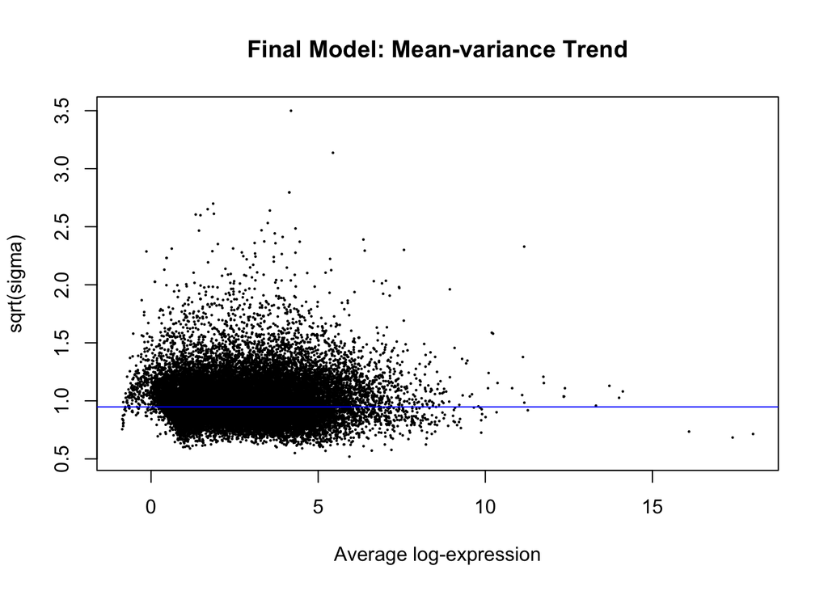

```r
veBayesFit <- eBayes(vfit)
plotSA(veBayesFit, main = "Final Model: Mean-variance Trend")
```

decideTests() identifies which genes are significantly differentially expressed for each contrast from a fit object containing p-values and test statistics.

```r
sumTable <-
  summary(decideTests(
    vfit,  # object
    # by default the method = "separate"
    adjust.method = "BH",
    adj.P.Val = 0.05,
    lfc = 1  # numeric, minimum absolute log2-fold change required
  ))

head(sumTable)
```

```
##        dirty_vs_clean
## Down                0
## NotSig          21643
## Up                  6
```

————————————–DEG TABLES——————————–

For each comparison…extract table of the top-ranked genes (DEGs) from a linear model fit AND output a table.

NOTE: Log2FC of 1 is equivalent to linear fold change of 2.

```r
coef <- 1
for (i in allComparisons) {

  # p < 1, log2fc > 0 ----------------------------------------------------------
  vTopTableAll <-
    topTable(
      veBayesFit,
      coef = coef,
      n = Inf,
      p.value = 1,
      lfc = 0
    )
  #output as txt file
  path <- paste("DEG_", i, "_FDRq1_Log2FC0.txt", sep = "")
  write.table(
    vTopTableAll,
    path,
    sep = "\t",
    row.names = TRUE,
    quote = FALSE
  )

  # p < 0.05, log2fc > 1 -------------------------------------------------------
  vTopTable2 <-
    topTable(
      veBayesFit,
      coef = coef,
      n = Inf,
      p.value = 0.05,
      lfc = 1
    )
  path <- paste("DEG_", i, "_FDRq0.05_Log2FC1.txt", sep = "")
  write.table(
    vTopTable2,
    path,
    sep = "\t",
    row.names = TRUE,
    quote = FALSE
  )

  # increment the coefficient --------------------------------------------------
  coef <- coef + 1
}
```

———————————-VOLCANO PLOTS———————————

Using the DEG tables we made, graph a volcano plot. Read in file.

```r
dirty_vs_clean <-
  read.table(
    "DEG_dirty_vs_clean_FDRq1_Log2FC0.txt",
    header = TRUE,
    sep = "\t",
    stringsAsFactors = F
  )
```

```r
summary(decideTests(
    vfit,  # object
    adjust.method = "BH", # by default the method = "separate"
    p.value = 0.05,
    lfc = 1
  ))
```

```
##        dirty_vs_clean
## Down                0
## NotSig          21643
## Up                  6
```

```r
color_values <- vector()
max <- nrow(dirty_vs_clean)

for(i in 1:max){
  if (dirty_vs_clean$adj.P.Val[i] < 0.05){
    if (dirty_vs_clean$logFC[i] > 1){
      color_values <- c(color_values, 1) # 1 when logFC > 1 and pval < 0.05
    }
    else if (dirty_vs_clean$logFC[i] < -1){
      color_values <- c(color_values, 2) # 2 when logFC < -1 and pval < 0.05
    }
    else{
      color_values <- c(color_values, 3) # 3 when -1 =< logFC <= 1 and pval < 0.05
    }
  }
  else{
    color_values <- c(color_values, 3) # 3 when pval >= 0.05
  }
}

dirty_vs_clean$color_p0.05_lfc1 <- factor(color_values)
```

```r
hadjpval <- (-log10(max(dirty_vs_clean$adj.P.Val[dirty_vs_clean$adj.P.Val < 0.05], na.rm=TRUE)))
hadjpval
```

```
## [1] 1.569028
```

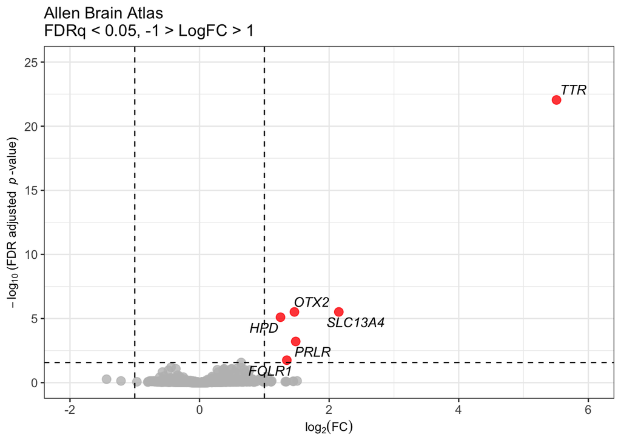

```r
p <-
  ggplot(data = dirty_vs_clean,
         aes(x = logFC, # x-axis is logFC
             y = -log10(adj.P.Val), # y-axis will be log10 of adj.P.Val
             color = color_p0.05_lfc1)) + # color is based on factored Color column
  geom_point(alpha = 0.8, size = 3) + # create scatterplot, alpha makes points transparent
  theme_bw() +
  theme(legend.position = "none") + # no legend
  xlim(c(-2, 6)) + ylim(c(0, 25)) + # x and y axis limits
  scale_color_manual(values = c("red", "grey")) + # set factor colors
  labs(
    title = "", # no main title
    x = expression(log[2](FC)), # x-axis title
    y = expression(-log[10] ~ "(FDR adjusted " ~ italic("p") ~ "-value)") # y-axis title
  ) +
  theme(axis.title.x = element_text(size = 10),
        axis.text.x = element_text(size = 10)) +
  theme(axis.title.y = element_text(size = 10),
        axis.text.y = element_text(size = 10)) +
  geom_hline(yintercept = hadjpval,
                     colour = "#000000",
                     linetype = "dashed") +
    geom_vline(xintercept = 1,
             colour = "#000000",
             linetype = "dashed") +
  geom_vline(xintercept = -1,
             colour = "#000000",
             linetype = "dashed") +
  ggtitle("Allen Brain Atlas\nFDRq < 0.05, -1 > LogFC > 1") +
  geom_text_repel(data = subset(dirty_vs_clean, dirty_vs_clean$color_p0.05_lfc1 == 1 |
                                  dirty_vs_clean$color_p0.05_lfc1 == 2),
                  aes(x = logFC, y = -log10(adj.P.Val), label = gene_symbol),
                  color = "black",
                  fontface="italic",
                  max.overlaps = getOption("ggrepel.max.overlaps", default = 20))
p
```